# Meta-analysis physiological costs of hibernation: Report 7 - OS Aestivation

Pablo Capilla-Lasheras

2026-05-06

This [R Markdown](http://rmarkdown.rstudio.com) Notebook contains the initial meta-analysis for the project ‘physiological ’costs’ of hibernation. Specifically, the meta-analysis of hibernation

## Dataset and calculation of effect sizes

The dataset for this meta-analysis has been collected from the literature and curated by Pablo Burraco, Marko Prokic and Tamara Petrovic. It contains data on physiological effects of hibernation in different systems. Here a quick snapshot of the first lines of the dataset:

```r
# dataset with raw data
data <- openxlsx::read.xlsx(
  here(
    "./01_data/raw_data/Burraco_et_al_estivation_hibernation.xlsx"
  ),
  colNames = T,
  sheet = 1
)

paged_table(data, options = list(rows.print = 20))
```

|  | Reference | Year | StudyID | Species | Thermoregulation | Ver_Invert | Experiment_venue | Biological.process | Tissue | Biomarker_cat_2 | Specific_biomarker | Unit | Euthermia_N | Euthermia_M | Euthermia_SD | Euthermia_SE | Hib_N | Hib_M | Hib_SD | Hib_SE |
| --- | --- | --- | --- | --- | --- | --- | --- | --- | --- | --- | --- | --- | --- | --- | --- | --- | --- | --- | --- | --- |
| 1 | Hudson et al., 2005 | 2005 | study182 | Ranoidea alboguttata | Ectothermic | Vertebrate | laboratory | estivation | muscle | Antioxidant | SOD | Expression levels | 6 | 6.425430e+00 | NA | 1.320290e+00 | 6 | 2.171150e+00 | NA | 7.041600e-01 |
| 2 | Hudson et al., 2005 | 2005 | study182 | Ranoidea alboguttata | Ectothermic | Vertebrate | laboratory | estivation | muscle | Antioxidant | CAT | Expression levels | 5 | 1.280654e+02 | NA | 3.814713e+01 | 6 | 1.777929e+02 | NA | 4.564032e+01 |
| 3 | Hudson et al., 2005 | 2005 | study182 | Ranoidea alboguttata | Ectothermic | Vertebrate | laboratory | estivation | muscle | Antioxidant | GPx | Expression levels | 6 | 6.253102e+02 | NA | 1.449132e+02 | 6 | 4.287841e+02 | NA | 5.756824e+01 |
| 4 | Bhunia et al., 2016 | 2016 | study405 | Pila globosa | Ectothermic | Invertebrate | laboratory | estivation | hemocyte | Antioxidant | CAT | k mg protein/min | 10 | 3.470000e-03 | NA | 1.100000e-03 | 10 | 1.498000e-02 | NA | 4.270000e-03 |
| 5 | Bhunia et al., 2016 | 2016 | study405 | Pila globosa | Ectothermic | Invertebrate | laboratory | estivation | hemocyte | Antioxidant | GST | µmol mg protein/min | 10 | 7.442860e+00 | NA | 2.285700e-01 | 10 | 6.000000e+00 | NA | 8.571000e-02 |
| 6 | Bhunia et al., 2016 | 2016 | study405 | Pila globosa | Ectothermic | Invertebrate | laboratory | estivation | hemocyte | Antioxidant | SOD | U/mg protein | 10 | 7.981790e+00 | NA | 1.530050e+00 | 10 | 7.701280e+00 | NA | 9.945300e-01 |
| 7 | Bhunia et al., 2016 | 2016 | study405 | Pila globosa | Ectothermic | Invertebrate | laboratory | estivation | hemolymph | Antioxidant | CAT | k mg protein/min | 10 | 3.300000e-04 | NA | 5.000000e-05 | 10 | 2.200000e-04 | NA | 4.000000e-05 |
| 8 | Bhunia et al., 2016 | 2016 | study405 | Pila globosa | Ectothermic | Invertebrate | laboratory | estivation | hemolymph | Antioxidant | SOD | U/mg protein | 10 | 5.344000e-01 | NA | 1.040000e-01 | 10 | 2.096000e-01 | NA | 1.600000e-02 |
| 9 | Bhunia et al., 2016 | 2016 | study405 | Pila globosa | Ectothermic | Invertebrate | laboratory | estivation | hemolymph | Antioxidant | GST | µmol mg protein/min | 10 | 1.665560e+00 | NA | 2.152300e-01 | 10 | 7.417200e-01 | NA | 3.311000e-02 |
| 10 | Bhunia et al., 2016 | 2016 | study405 | Pila globosa | Ectothermic | Invertebrate | laboratory | estivation | hemocyte | ROS | superoxide anion | O.D. 10 on 6th/ cells min | 10 | 1.320000e-03 | NA | 8.000000e-05 | 10 | 3.130000e-03 | NA | 8.500000e-04 |

[output cut: 374 more lines]

As a summary of the *initial dataset*:

- Number of studies: 20
- Number of species: 12

For this initial meta-analysis, I am going to include all oxidative stress (OS) markers and calculate the standarised mean difference (g; with heteroscedastic population variances) as the effect size of analysis comparing **aestivation** *versus* **euthermia**. Positive SMD values indicate higher OS values in *aestivation* while negative SMD indicate lower OS values in aestivation. This is a summary of the effect size calculation based on the dataset above:

```r
# ES data
# note that there is a very large effect size (~40), we have checked this effect size and the raw data and the data as collected is correct
data <- readRDS(
  here(
    "./01_data/processed_RDS_data_files/07_OS_metaanalysis_aestivation_full_data.RDS"
  )
)
data$obsID <- 1:nrow(data) # observation ID

# handling species names for phylogenetic-controlled models
data$Species <- replace_values(
  data$Species,
  "Ranoidea alboguttata" ~ "Cyclorana alboguttata" # correcting synomyn names manuallty
)

data$scientific_name <- gsub(
  x = data$Species,
  pattern = "_",
  replacement = " "
)

data$scientific_name_phylo <- data$scientific_name

## data for SMD
df_SMD <- data %>%
  filter(!is.na(SMDH)) %>%
  filter(!is.na(SMDH.sv))

# matrix with phylogentic correlations
phylo_cor <- readRDS(
  here(
    "./01_data/processed_RDS_data_files/07_OS_phylogenetic_correlations_aestivation.RDS"
  )
)

phylo_tree <- readRDS(
  here(
    "./01_data/processed_RDS_data_files/07_OS_phylogenetic_tree_aestivation.RDS"
  )
)

tree <- ggtree(phylo_tree, size = 1.2) +
  xlim_tree(c(0, 35)) +
  geom_tiplab(
    aes(
      label = paste0(
        "italic('",
        sub(x = label, pattern = "_", replacement = " "),
        "')"
      )
    ),
    parse = TRUE,
    offset = 0.5,
    size = 5,
    hjust = 0
  )

ggsave(
  filename = here(
    "./03_plots/03_aestivation/00a_OS_phylo_tree.png"
  ),
  plot = tree,
  device = "png",
  height = 150,
  width = 90,
  units = "mm"
)

ggsave(
  filename = here(
    "./03_plots/03_aestivation/00a_OS_phylo_tree.pdf"
  ),
  plot = tree,
  height = 150,
  width = 90,
  units = "mm"
)
```

Summary of SMD effect size and number of observations included in the meta-analysis:

```r
summary(df_SMD$SMDH)
```

```
##    Min. 1st Qu.  Median    Mean 3rd Qu.    Max.
## -6.3124 -0.6132  0.1880  0.3318  1.0275 43.9933
```

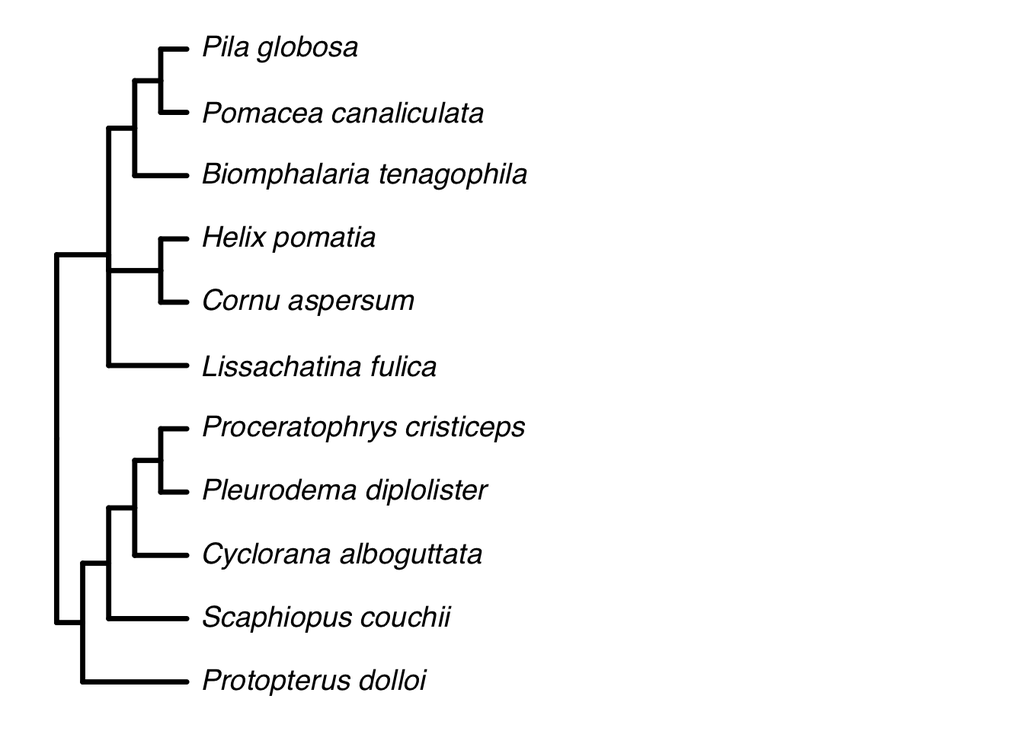

```r
print(tree)
```

## Initial meta-analysis:

This initial model contains only the intercept and four random effects to account for phylogenetic variation and variation between and within studies beyond sampling variance.

```r
## calculate var-cover matrix to control for correlated effect sizes within study and tissue
V <- vcalc(
  vi = SMDH.sv,
  cluster = StudyID,
  subgroup = Tissue,
  grp1 = Hib_M,
  grp2 = Euthermia_M,
  w1 = Hib_N,
  w2 = Euthermia_N,
  data = df_SMD
)

# model
model_SMD <- rma.mv(
  yi = SMDH,
  V = V,
  mods = ~1,
  random = list(
    ~ 1 | scientific_name_phylo,
    ~ 1 | Species,
    ~ 1 | obsID,
    ~ 1 | StudyID
  ),
  data = df_SMD,
  R = list(scientific_name_phylo = phylo_cor),
  method = "REML",
  control = list(optimizer = "BFGS"),
  verbose = F
)
```

```r
saveRDS(
  object = model_SMD,
  file = here(
    './04_models/03_aestivation/01a_metamodel_aestivation_OS.RDS'
  )
)
model_SMD <- readRDS(
  file = here(
    './04_models/03_aestivation/01a_metamodel_aestivation_OS.RDS'
  )
)
summary(model_SMD)
```

```
##
## Multivariate Meta-Analysis Model (k = 340; method: REML)
##
##    logLik   Deviance        AIC        BIC       AICc
## -579.8381  1159.6763  1169.6763  1188.8063  1169.8565
##
## Variance Components:
##
##             estim    sqrt  nlvls  fixed                 factor    R
## sigma^2.1  0.0001  0.0121     11     no  scientific_name_phylo  yes
## sigma^2.2  0.0187  0.1366     11     no                Species   no
## sigma^2.3  0.6658  0.8160    340     no                  obsID   no
## sigma^2.4  0.2214  0.4705     19     no                StudyID   no
##
## Test for Heterogeneity:
## Q(df = 339) = 940.3509, p-val < .0001
##
## Model Results:
##
## estimate      se    zval    pval    ci.lb   ci.ub
##   0.1792  0.1390  1.2887  0.1975  -0.0933  0.4517
##
## ---
## Signif. codes:  0 '***' 0.001 '**' 0.01 '*' 0.05 '.' 0.1 ' ' 1
```

```r
i2_SMD <- round(i2_ml(model_SMD), digits = 4) # heterogeneity random effects
```

Proportion of variation left after accounting for sampling variance and proportion accounted by each random effect:

```r
knitr::kable(
  x = data.frame(
    Variable = names(i2_SMD),
    i2_value_percentage = as.numeric(round(i2_SMD, digits = 3))
  )
) %>%
  kableExtra::kable_styling(full_width = F)
```

| Variable | i2_value_percentage |
| --- | --- |
| I2_Total | 64.763 |
| I2_scientific_name_phylo | 0.010 |
| I2_Species | 1.334 |
| I2_obsID | 47.593 |
| I2_StudyID | 15.826 |

### Plot of results of intercept-only model:

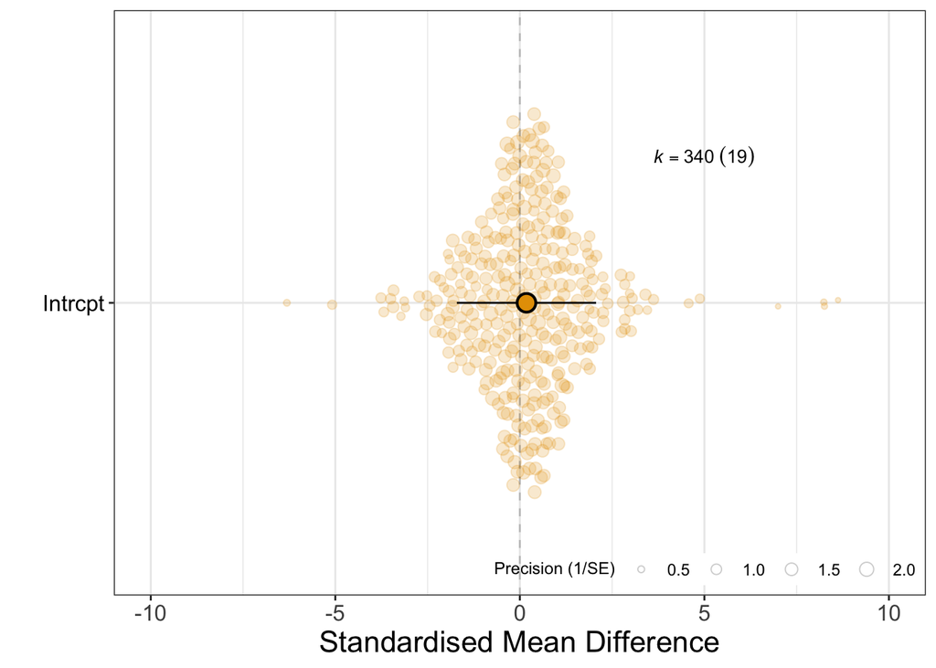

```r
overall_plot <- orchard_plot(
  object = model_SMD,
  mod = "1",
  group = 'StudyID',
  k.pos = 5,
  trunk.size = 1,
  alpha = 0.2,
  cb = FALSE,
  xlab = "Standardised Mean Difference",
  transfm = "none"
) +
  scale_fill_okabe_ito() +
  scale_color_okabe_ito() +
  theme(
    axis.text = element_text(size = 12),
    axis.text.y = element_text(size = 12, angle = 0),
    axis.title = element_text(size = 16)
  ) +
  scale_y_continuous(
    limits = c(-10, 10),
    breaks = seq(-15, 15, 5),
    label = seq(-15, 15, 5)
  )

overall_plot
```

```r
ggsave(
  filename = here(
    "./03_plots/03_aestivation/01a_overall_plot_aestivation_OS.png"
  ),
  plot = overall_plot,
  device = "png",
  height = 110,
  width = 185,
  units = "mm"
)

ggsave(
  filename = here(
    "./03_plots/03_aestivation/01a_overall_plot_aestivation_OS.pdf"
  ),
  plot = overall_plot,
  height = 110,
  width = 185,
  units = "mm"
)
```

### Publication bias: small-study effects

```r
df_SMD$inv_eff_ss <- (1 / df_SMD$Hib_N) + (1 / df_SMD$Euthermia_N)

model_SMD_pb <- rma.mv(
  yi = SMDH,
  V = V,
  mods = ~ 1 + sqrt(inv_eff_ss),
  random = list(
    ~ 1 | scientific_name_phylo,
    ~ 1 | Species,
    ~ 1 | obsID,
    ~ 1 | StudyID
  ),
  data = df_SMD,
  R = list(scientific_name_phylo = phylo_cor),
  method = "REML",
  control = list(optimizer = "BFGS"),
  verbose = F
)
```

```r
saveRDS(
  object = model_SMD_pb,
  file = here(
    './04_models/03_aestivation/06a_pb_metamodel_aestivation_OS.RDS'
  )
)
model_SMD_pb <- readRDS(
  file = here(
    './04_models/03_aestivation/06a_pb_metamodel_aestivation_OS.RDS'
  )
)

summary(model_SMD_pb)
```

```
##
## Multivariate Meta-Analysis Model (k = 340; method: REML)
##
##    logLik   Deviance        AIC        BIC       AICc
## -578.4863  1156.9725  1168.9725  1191.9108  1169.2263
##
## Variance Components:
##
##             estim    sqrt  nlvls  fixed                 factor    R
## sigma^2.1  0.0001  0.0116     11     no  scientific_name_phylo  yes
## sigma^2.2  0.0189  0.1375     11     no                Species   no
## sigma^2.3  0.6698  0.8184    340     no                  obsID   no
## sigma^2.4  0.2252  0.4746     19     no                StudyID   no
##
## Test for Residual Heterogeneity:
## QE(df = 338) = 940.2704, p-val < .0001
##
## Test of Moderators (coefficient 2):
## QM(df = 1) = 0.0019, p-val = 0.9650
##
## Model Results:
##
##                   estimate      se     zval    pval    ci.lb   ci.ub
## intrcpt             0.2057  0.6193   0.3321  0.7398  -1.0082  1.4195
## sqrt(inv_eff_ss)   -0.0462  1.0524  -0.0439  0.9650  -2.1088  2.0164
##
## ---
## Signif. codes:  0 '***' 0.001 '**' 0.01 '*' 0.05 '.' 0.1 ' ' 1
```

### Publication bias: time-lag effects

```r
df_SMD$year_scl <- scale(df_SMD$Year)

model_SMD_tl <- rma.mv(
  yi = SMDH,
  V = V,
  mods = ~ 1 + year_scl,
  random = list(
    ~ 1 | scientific_name_phylo,
    ~ 1 | Species,
    ~ 1 | obsID,
    ~ 1 | StudyID
  ),
  data = df_SMD,
  R = list(scientific_name_phylo = phylo_cor),
  method = "REML",
  control = list(optimizer = "BFGS"),
  verbose = F
)
```

```r
saveRDS(
  object = model_SMD_tl,
  file = here(
    './04_models/03_aestivation/07a_timelag_metamodel_aestivation_OS.RDS'
  )
)
model_SMD_tl <- readRDS(
  file = here(
    './04_models/03_aestivation/07a_timelag_metamodel_aestivation_OS.RDS'
  )
)

summary(model_SMD_tl)
```

```
##
## Multivariate Meta-Analysis Model (k = 340; method: REML)
##
##    logLik   Deviance        AIC        BIC       AICc
## -576.2246  1152.4492  1164.4492  1187.3875  1164.7030
##
## Variance Components:
##
##             estim    sqrt  nlvls  fixed                 factor    R
## sigma^2.1  0.0000  0.0052     11     no  scientific_name_phylo  yes
## sigma^2.2  0.0005  0.0225     11     no                Species   no
## sigma^2.3  0.6671  0.8167    340     no                  obsID   no
## sigma^2.4  0.1979  0.4448     19     no                StudyID   no
##
## Test for Residual Heterogeneity:
## QE(df = 338) = 908.0763, p-val < .0001
##
## Test of Moderators (coefficient 2):
## QM(df = 1) = 3.7908, p-val = 0.0515
##
## Model Results:
##
##           estimate      se    zval    pval    ci.lb   ci.ub
## intrcpt     0.1475  0.1256  1.1744  0.2403  -0.0986  0.3935
## year_scl    0.2729  0.1402  1.9470  0.0515  -0.0018  0.5477  .
##
## ---
## Signif. codes:  0 '***' 0.001 '**' 0.01 '*' 0.05 '.' 0.1 ' ' 1
```

The results above suggest some degree of time-lag bias.

```r
results <- mod_results(model_SMD_tl, mod = "year_scl", group = "StudyID")
time_bias <- orchaRd::bubble_plot(
  model_SMD_tl,
  mod = 'year_scl',
  group = 'StudyID',
  alpha = 0.2,
  cb = FALSE,
  xlab = "Year of publication (scaled)",
  transfm = "none",
) +
  theme(
    axis.text = element_text(size = 12),
    axis.text.y = element_text(size = 12, angle = 0),
    axis.title = element_text(size = 16)
  )

ggsave(
  filename = here(
    "./03_plots/03_aestivation/06a_overall_plot_aestivation_OS.png"
  ),
  device = 'png',
  plot = time_bias,
  height = 110,
  width = 185,
  units = "mm"
)
ggsave(
  filename = here(
    "./03_plots/03_aestivation/06a_overall_plot_aestivation_OS.pdf"
  ),
  plot = time_bias,
  height = 110,
  width = 185,
  units = "mm"
)
```

## Meta-analysis with all organisms but including different OS markers:

Number of observations for each type:

```r
table(df_SMD$Biomarker_cat_2)
```

[output not shown]

```r
model_SMD_biomarker <- rma.mv(
  yi = SMDH,
  V = V,
  mods = ~ Biomarker_cat_2 - 1,
  random = list(
    ~ 1 | scientific_name_phylo,
    ~ 1 | Species,
    ~ 1 | obsID,
    ~ 1 | StudyID
  ),
  data = df_SMD,
  R = list(scientific_name_phylo = phylo_cor),
  method = "REML",
  control = list(optimizer = "BFGS"),
  verbose = F
)
```

```r
saveRDS(
  object = model_SMD_biomarker,
  file = here(
    './04_models/03_aestivation/02a_metareg_biomarker_aestivation_OS.RDS'
  )
)
model_SMD_biomarker <- readRDS(
  file = here(
    './04_models/03_aestivation/02a_metareg_biomarker_aestivation_OS.RDS'
  )
)
summary(model_SMD_biomarker)
```

```
##
## Multivariate Meta-Analysis Model (k = 340; method: REML)
##
##    logLik   Deviance        AIC        BIC       AICc
## -573.9711  1147.9423  1163.9423  1194.4792  1164.3827
##
## Variance Components:
##
##             estim    sqrt  nlvls  fixed                 factor    R
## sigma^2.1  0.0002  0.0143     11     no  scientific_name_phylo  yes
## sigma^2.2  0.0166  0.1287     11     no                Species   no
## sigma^2.3  0.6744  0.8212    340     no                  obsID   no
## sigma^2.4  0.2192  0.4682     19     no                StudyID   no
##
## Test for Residual Heterogeneity:
## QE(df = 336) = 929.5485, p-val < .0001
##
## Test of Moderators (coefficients 1:4):
## QM(df = 4) = 6.6204, p-val = 0.1574
##
## Model Results:
##
##                                  estimate      se     zval    pval    ci.lb
## Biomarker_cat_2Antioxidant         0.1203  0.1414   0.8509  0.3948  -0.1568
## Biomarker_cat_2Oxidative_damage    0.4129  0.1922   2.1480  0.0317   0.0361
## Biomarker_cat_2Regulatory         -0.1613  0.5561  -0.2901  0.7718  -1.2511
## Biomarker_cat_2ROS                 0.7195  0.5275   1.3642  0.1725  -0.3143
##                                   ci.ub
## Biomarker_cat_2Antioxidant       0.3973
## Biomarker_cat_2Oxidative_damage  0.7896  *
## Biomarker_cat_2Regulatory        0.9285
## Biomarker_cat_2ROS               1.7533
##
## ---
## Signif. codes:  0 '***' 0.001 '**' 0.01 '*' 0.05 '.' 0.1 ' ' 1
```

### Plot of results of biomarker meta-regression:

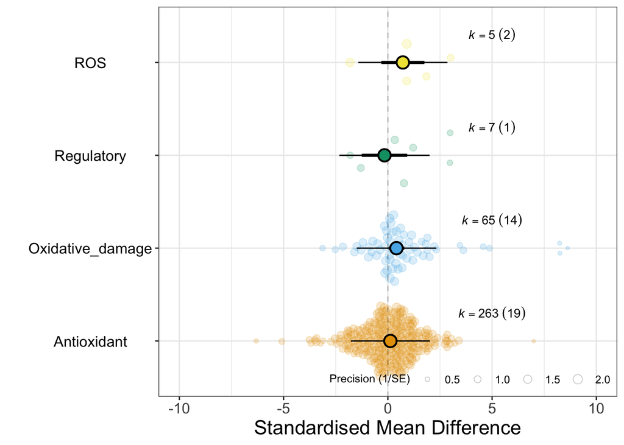

```r
biomarker_plot <- orchard_plot(
  object = model_SMD_biomarker,
  mod = 'Biomarker_cat_2',
  group = 'StudyID',
  k.pos = 5,
  trunk.size = 1,
  alpha = 0.2,
  cb = FALSE,
  xlab = "Standardised Mean Difference",
  transfm = "none"
) +
  scale_fill_okabe_ito() +
  scale_color_okabe_ito() +
  theme(
    axis.text = element_text(size = 12),
    axis.text.y = element_text(size = 12, angle = 0),
    axis.title = element_text(size = 16)
  ) +
  scale_y_continuous(
    limits = c(-10, 10),
    breaks = seq(-15, 15, 5),
    label = seq(-15, 15, 5)
  )

biomarker_plot
```

```r
ggsave(
  filename = here(
    "./03_plots/03_aestivation/02a_biomarker_OS.png"
  ),
  plot = biomarker_plot,
  device = "png",
  height = 110,
  width = 185,
  units = "mm"
)

ggsave(
  filename = here(
    "./03_plots/03_aestivation/02a_biomarker_OS.pdf"
  ),
  plot = biomarker_plot,
  height = 110,
  width = 185,
  units = "mm"
)
```